# 07_analysis_manufacturer_progression_plot.qmd

## All documents so far

### Loading data

Here we will make a new data file under the data-folder named; “01_…_load.tsv”. We will combine the three data sets that we have.

The files should be downloaded with the provided links and be placed in the “_raw” folder which should be in the “data” folder.

From:

[figure not shown]

Kaggle: Vaccine and Manufacturer data

[figure not shown]

Kaggle: World population data

These have to be put into “../data/_raw” in your Rstudio. Now to loading:

## Clean data 1

Loading libraries:

```r
#|echo: false

# Loading libraries
library(tidyverse)
library(dplyr)
library(readr)
```

We load the data set:

```r
#|echo: false

# Importing load data
manufacturer_update <- read_tsv("../data/01_manufacturer_load.tsv")
vaccines_update <- read_tsv("../data/01_vaccines_load.tsv")
world_population_update <- read_tsv("../data/01_world_population_load.tsv")
```

We inspect the structure:

```r
# Looking at the data
glimpse(manufacturer_update)
```

```
Rows: 35,623
Columns: 4
$ location           <chr> "Argentina", "Argentina", "Argentina", "Argentina",…
$ date               <date> 2020-12-29, 2020-12-29, 2020-12-29, 2020-12-29, 20…
$ vaccine            <chr> "Moderna", "Oxford/AstraZeneca", "Sinopharm/Beijing…
$ total_vaccinations <dbl> 2, 3, 1, 20481, 2, 3, 1, 40583, 2, 3, 1, 43388, 2, …
```

```r
glimpse(vaccines_update)
```

```
Rows: 86,512
Columns: 15
$ country                             <chr> "Afghanistan", "Afghanistan", "Afg…
$ iso_code                            <chr> "AFG", "AFG", "AFG", "AFG", "AFG",…
$ date                                <date> 2021-02-22, 2021-02-23, 2021-02-2…
$ total_vaccinations                  <dbl> 0, NA, NA, NA, NA, NA, 8200, NA, N…
$ people_vaccinated                   <dbl> 0, NA, NA, NA, NA, NA, 8200, NA, N…
$ people_fully_vaccinated             <dbl> NA, NA, NA, NA, NA, NA, NA, NA, NA…
$ daily_vaccinations_raw              <dbl> NA, NA, NA, NA, NA, NA, NA, NA, NA…
$ daily_vaccinations                  <dbl> NA, 1367, 1367, 1367, 1367, 1367, …
$ total_vaccinations_per_hundred      <dbl> 0.00, NA, NA, NA, NA, NA, 0.02, NA…
$ people_vaccinated_per_hundred       <dbl> 0.00, NA, NA, NA, NA, NA, 0.02, NA…
$ people_fully_vaccinated_per_hundred <dbl> NA, NA, NA, NA, NA, NA, NA, NA, NA…
$ daily_vaccinations_per_million      <dbl> NA, 34, 34, 34, 34, 34, 34, 40, 45…
$ vaccines                            <chr> "Johnson&Johnson, Oxford/AstraZene…
$ source_name                         <chr> "World Health Organization", "Worl…
$ source_website                      <chr> "https://covid19.who.int/", "https…
```

```r
glimpse(world_population_update)
```

```
Rows: 234
Columns: 17
$ Rank                          <dbl> 36, 138, 34, 213, 203, 42, 224, 201, 33,…
$ CCA3                          <chr> "AFG", "ALB", "DZA", "ASM", "AND", "AGO"…
$ `Country/Territory`           <chr> "Afghanistan", "Albania", "Algeria", "Am…
$ Capital                       <chr> "Kabul", "Tirana", "Algiers", "Pago Pago…
$ Continent                     <chr> "Asia", "Europe", "Africa", "Oceania", "…
$ `2022 Population`             <dbl> 41128771, 2842321, 44903225, 44273, 7982…
$ `2020 Population`             <dbl> 38972230, 2866849, 43451666, 46189, 7770…
$ `2015 Population`             <dbl> 33753499, 2882481, 39543154, 51368, 7174…
$ `2010 Population`             <dbl> 28189672, 2913399, 35856344, 54849, 7151…
$ `2000 Population`             <dbl> 19542982, 3182021, 30774621, 58230, 6609…
$ `1990 Population`             <dbl> 10694796, 3295066, 25518074, 47818, 5356…
$ `1980 Population`             <dbl> 12486631, 2941651, 18739378, 32886, 3561…
$ `1970 Population`             <dbl> 10752971, 2324731, 13795915, 27075, 1986…
$ `Area (km²)`                  <dbl> 652230, 28748, 2381741, 199, 468, 124670…
$ `Density (per km²)`           <dbl> 63.0587, 98.8702, 18.8531, 222.4774, 170…
$ `Growth Rate`                 <dbl> 1.0257, 0.9957, 1.0164, 0.9831, 1.0100, …
$ `World Population Percentage` <dbl> 0.52, 0.04, 0.56, 0.00, 0.00, 0.45, 0.00…
```

We start of by cleaning manufacturer data:

```r
# Cleaning manufacturer data
manufacturer_cleaned <- manufacturer_update |>
  distinct() |> #This is to remove any duplicates there might be
  drop_na(location, date, vaccine) |> #removing the missing
  mutate(date = as.Date(date, format = "%Y-%m-%d")) #Here we make sure the dates are in the corret format
```

We do the same with the vaccine data

```r
# Cleaning vaccine data
vaccines_cleaned <- vaccines_update |>
  distinct() |>
  mutate(
    date = as.Date(date, format = "%Y-%m-%d"),
    total_vaccinations = if_else(is.na(total_vaccinations),
                                 NA_real_,
                                 total_vaccinations),
    daily_vaccinations = if_else(is.na(daily_vaccinations),
                                 NA_real_,
                                 daily_vaccinations),
    vaccines = replace_na(vaccines, "unknown") #Replace rows where the vaccines are missing with unknown, so it doesn't get grouped with the numeric NA
  ) |>

  # Has just been added - removes columns and seperates values in single cell
  select(-iso_code, # Removing irrelavent columns
         -source_website,
         -source_name,
         -daily_vaccinations_raw) |>
  separate_rows(vaccines, # Seperates the observations so there is only 1 value pr cell
                sep = ",")
```

Since the world population data is already tidy, and we only want to left join it to our other data to make a more comprehensive data set, we have decided to remove some irrelevant columns and then proceed.

```r
# Cleaning world population data
world_population_cleaned <- world_population_update |>
  select(`Country/Territory`, # Selecting the only relevant columns form the data
         `Continent`,
         `2022 Population`,
         `2020 Population`,
         `Growth Rate`)
```

Now we write the files:

```r
# Writing 02_cleaned files
## Manufacturer cleaned
write_tsv(x = manufacturer_cleaned,
          file = str_c("../data/", "02_manufacturer_cleaned.tsv"))

## Vaccnies cleaned
write_tsv(x = vaccines_cleaned,
          file = str_c("../data/", "02_vaccines_cleaned.tsv"))

## World population cleaned
write_tsv(x = world_population_cleaned,
          file = str_c("../data/", "02_world_population_cleaned.tsv"))
```

### 1st analysis - world map

## Analysis and plots - world plots

First of we’d like to make a heat map over the world when taking vaccine amount in to account.

We load necessary libraries:

Load the data:

```r
# Filtering data by country for easier overview

manufac_world_pop <- manufac_world_pop |>
  arrange(by_group=Country)
```

### Plotting the actual plot

importing another data set so we can make a heat map. We will combine the data here but not make a new data file because of it being to big to load.

```r
# Loading the maps package
#| echo: false
library(maps)
world_map <- map_data("world") # This gives us long and lat of each country

# Now we merge the world map and the data we just did:
world_map_vaccinated <- world_map |>
  left_join(manufac_world_pop, by = c("region" = "Country"), relationship = "many-to-many")
```

Plotting heat map for different dates through the data set:

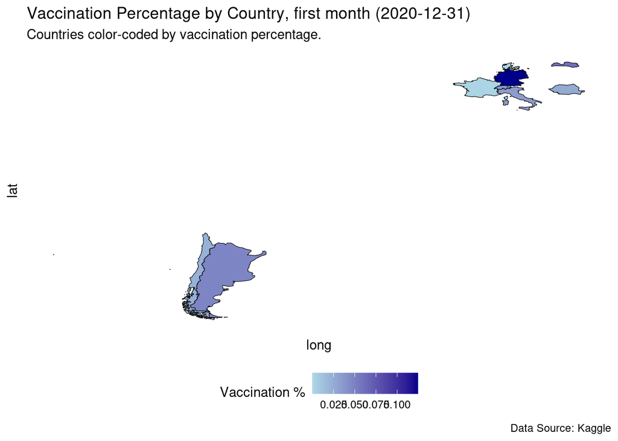

```r
# Plotting with ggplot
## First month of the vaccines
p1 <- world_map_vaccinated |>
  filter(date <= as.Date("2020-12-31")) |> # Filter up to a certain date
  group_by(region) |> # Grouping by country
  summarise(long, # Keeping the following variables and making sure that only the
            lat,  # highest percentage is recorded for each country
            group,
            `Percentage Vaccinated`=max(`Percentage Vaccinated`, na.rm = TRUE)) |>
  ungroup() |> # Ungrouping
  ggplot(aes(x = long, y = lat, group = group, fill = `Percentage Vaccinated`)) +
  geom_polygon(color = "black", size = 0.2) + # Making the actual plot
  scale_fill_gradient(low = "lightblue",
                       high = "darkblue",
                       na.value = "grey50",
                       name = "Vaccination %") +
  theme_minimal() +
  labs(
    title = "Vaccination Percentage by Country, first month (2020-12-31)",
    subtitle = "Countries color-coded by vaccination percentage.",
    caption = "Data Source: Kaggle") +
  theme(
    axis.text = element_blank(), # Making sure that axis are correctly formated
    axis.ticks = element_blank(),
    panel.grid = element_blank(),
    legend.position = "bottom"
  )
# Displaying the plot
p1
```

We repeat the process for different dates in the data set:

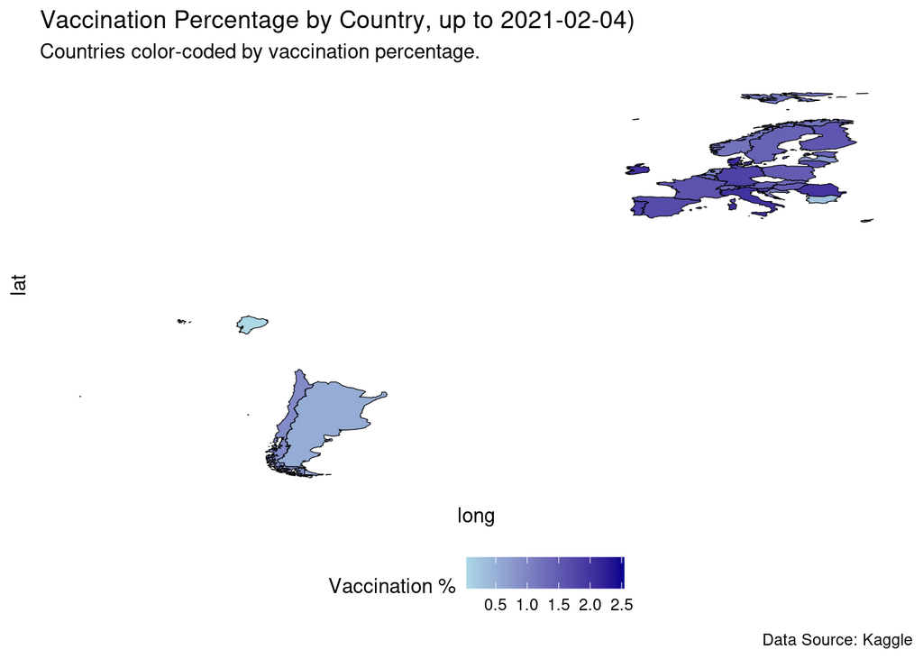

```r
# Plotting with ggplot
## Febuary 2021
p2 <- world_map_vaccinated |>
  filter(date <= as.Date("2021-02-04")) |>
  group_by(region) |>
  summarise(long,
            lat,
            group,
            `Percentage Vaccinated`=max(`Percentage Vaccinated`, na.rm = TRUE)) |>
  ungroup() |>
  ggplot(aes(x = long, y = lat, group = group, fill = `Percentage Vaccinated`)) +
  geom_polygon(color = "black", size = 0.2) +
  scale_fill_gradient(low = "lightblue",
                       high = "darkblue",
                       na.value = "grey50",
                       name = "Vaccination %") +
  theme_minimal() +
  labs(
    title = "Vaccination Percentage by Country, up to 2021-02-04)",
    subtitle = "Countries color-coded by vaccination percentage.",
    caption = "Data Source: Kaggle") +
  theme(
    axis.text = element_blank(),
    axis.ticks = element_blank(),
    panel.grid = element_blank(),
    legend.position = "bottom"
  )
# Displaying the plot
p2
```

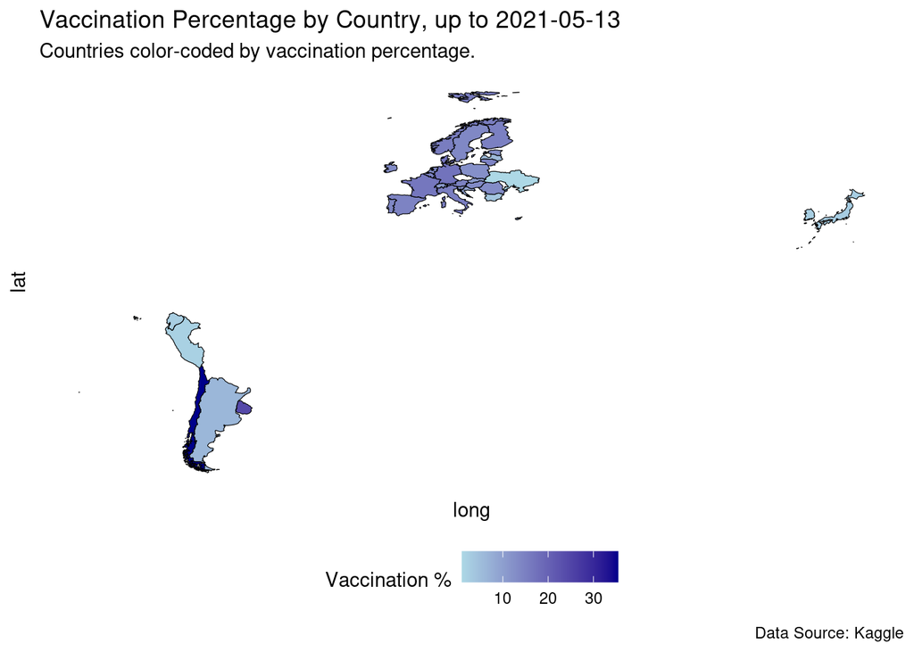

```r
# Plotting with ggplot
## May 2021
p3 <- world_map_vaccinated |>
  filter(date <= as.Date("2021-05-13")) |>
  group_by(region) |>
  summarise(long,
            lat,
            group,
            `Percentage Vaccinated`=max(`Percentage Vaccinated`, na.rm = TRUE)) |>
  ungroup() |>
  ggplot(aes(x = long, y = lat, group = group, fill = `Percentage Vaccinated`)) +
  geom_polygon(color = "black", size = 0.2) +
  scale_fill_gradient(low = "lightblue",
                       high = "darkblue",
                       na.value = "grey50",
                       name = "Vaccination %") +
  theme_minimal() +
  labs(
    title = "Vaccination Percentage by Country, up to 2021-05-13",
    subtitle = "Countries color-coded by vaccination percentage.",
    caption = "Data Source: Kaggle") +
  theme(
    axis.text = element_blank(),
    axis.ticks = element_blank(),
    panel.grid = element_blank(),
    legend.position = "bottom"
  )
# Displaying the plot
p3
```

[figure not shown]

```r
# Plotting with ggplot
## March 2022
p4 <- world_map_vaccinated |>
  filter(date <= as.Date("2022-03-25")) |>
  group_by(region) |>
  summarise(long,
            lat,
            group,
            `Percentage Vaccinated`=max(`Percentage Vaccinated`, na.rm = TRUE)) |>
  ungroup() |>
  ggplot(aes(x = long, y = lat, group = group, fill = `Percentage Vaccinated`)) +
  geom_polygon(color = "black", size = 0.2) +
  scale_fill_gradient(low = "lightblue",
                       high = "darkblue",
                       na.value = "grey50",
                       name = "Vaccination %") +
  theme_minimal() +
  labs(
    title = "Vaccination Percentage by Country, up to 2021-02-04",
    subtitle = "Countries color-coded by vaccination percentage.",
    caption = "Data Source: Kaggle") +
  theme(
    axis.text = element_blank(),
    axis.ticks = element_blank(),
    panel.grid = element_blank(),
    legend.position = "bottom"
  )
# Displaying the plot
p4
```

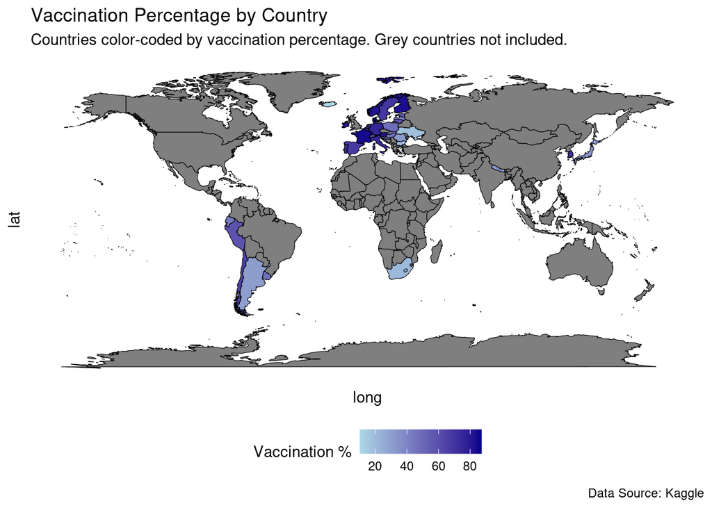

```r
# Plotting the whole world
## All the dates within the data set
p5 <- world_map_vaccinated |>
  group_by(region) |>
  summarise(long,
            lat,
            group,
            `Percentage Vaccinated`=max(`Percentage Vaccinated`, na.rm = TRUE)) |>
  ungroup() |>
  ggplot(aes(x = long, y = lat, group = group, fill = `Percentage Vaccinated`)) +
  geom_polygon(color = "black", size = 0.2) +
  scale_fill_gradient(low = "lightblue",
                       high = "darkblue",
                       na.value = "grey50",
                       name = "Vaccination %") +
  theme_minimal() +
  labs(
    title = "Vaccination Percentage by Country",
    subtitle = "Countries color-coded by vaccination percentage. Grey countries not included.",
    caption = "Data Source: Kaggle") +
  theme(
    axis.text = element_blank(),
    axis.ticks = element_blank(),
    panel.grid = element_blank(),
    legend.position = "bottom"
  )
# Displaying the plot
p5
```

```r
# Plotting continent
## All continents
world_map_vaccinated |>
  group_by(region) |>
  summarise(`Percentage Vaccinated`=max(`Percentage Vaccinated`, na.rm = TRUE)) |>
  ungroup()
```

```
# A tibble: 252 × 2
   region         `Percentage Vaccinated`
   <chr>                            <dbl>
 1 Afghanistan                     -Inf
 2 Albania                         -Inf
 3 Algeria                         -Inf
 4 American Samoa                  -Inf
 5 Andorra                         -Inf
 6 Angola                          -Inf
 7 Anguilla                        -Inf
 8 Antarctica                      -Inf
 9 Antigua                         -Inf
10 Argentina                         31.1
# ℹ 242 more rows
```

```r
p6 <- world_map_vaccinated |>
  group_by(region == c("Argentina", "Chile", "Ecuador", "Peru", "Uruguay")) |>
  summarise(long,
            lat,
            group,
            `Percentage Vaccinated`=max(`Percentage Vaccinated`, na.rm = TRUE)) |>
  ungroup() |>
  ggplot(aes(x = long, y = lat, group = group, fill = `Percentage Vaccinated`)) +
  geom_polygon(color = "black", size = 0.2) +
  scale_fill_gradient(low = "lightblue",
                       high = "darkblue",
                       na.value = "grey50",
                       name = "Vaccination %") +
  theme_minimal() +
  labs(
    title = "Vaccination Percentage by Country",
    subtitle = "Countries color-coded by vaccination percentage. Grey countries not included.",
    caption = "Data Source: Kaggle") +
  theme(
    axis.text = element_blank(),
    axis.ticks = element_blank(),
    panel.grid = element_blank(),
    legend.position = "bottom"
  )
```

[output not shown]

[figure not shown]

```r
# Displaying the plot
p6
```

Saving the plots:

```r
# Saving plots
# Using ggsave to save the picture as a png to the correct path.
## p1 - 2020/12/31
ggsave(filename = "../results/world_plot_2020-12-31.png", plot = p1, width = 10, height = 6, dpi = 300)

## p2 - 2021/02/04
ggsave(filename = "../results/world_plot_2021-02-04.png", plot = p2, width = 10, height = 6, dpi = 300)

## p3 - 2021/05/13
ggsave(filename = "../results/world_plot_2021-05-13.png", plot = p3, width = 10, height = 6, dpi = 300)

## p4 - 2022/03/25
ggsave(filename = "../results/world_plot_2022-03-25.png", plot = p4, width = 10, height = 6, dpi = 300)

## p5 - world 2022/03/25
ggsave(filename = "../results/whole_world_plot_2022-03-25.png", plot = p5, width = 10, height = 6, dpi = 300)
```

### 2nd analysis - countries progression

## Progression plots of different countries’ cumulative vaccination amounts

[figure not shown]

Now this plot needs to be put into the folder results:

```r
# Using ggsave to save the picture as a png to the correct path.
ggsave(filename = "../results/vaccination_progression.png", plot = Plot, width = 10, height = 6, dpi = 300)
```

### 4th analysis - another vaccine progression

## Progression of the different vaccines based on countries

First we load libraries:

We load data:

Now we can make a plot based on the dates on the x-axis and amount of each vaccine on the y-axis:

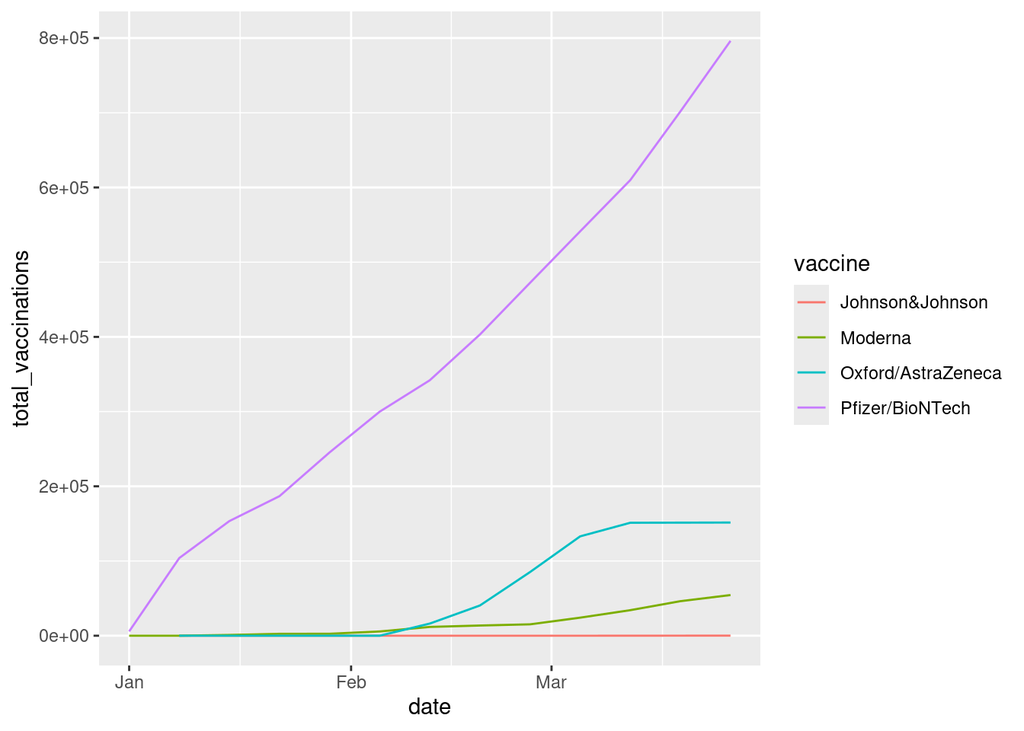

```r
# Plotting:
## Denmark the first 4 months of 2021
p1 <- data |>
  filter(Country == "Denmark",
         date >= "2021-01-01" & date <= "2021-04-01") |>
  ggplot(aes(x = date,
             y = total_vaccinations,
             color = vaccine)) +
  geom_line(aes(group = vaccine))

p1
```

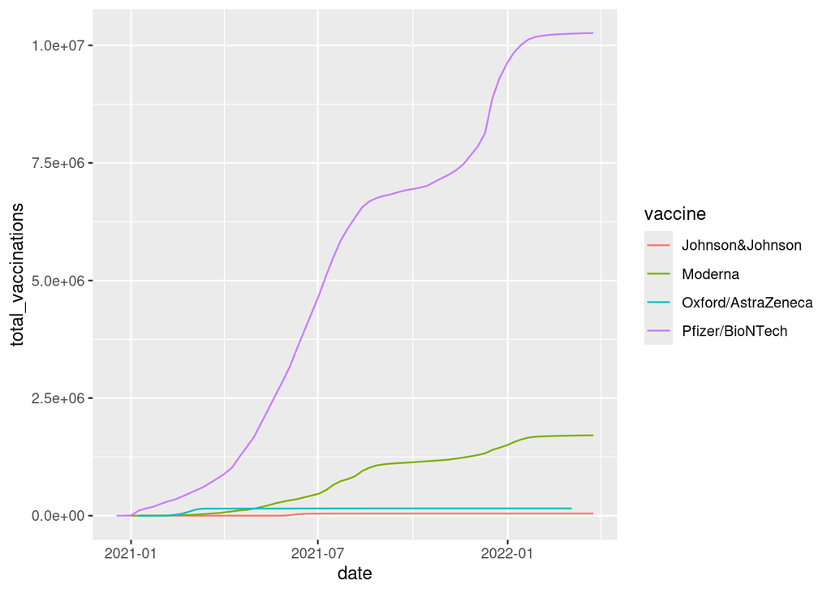

```r
## Denmark
p2 <- data |>
  filter(Country == "Denmark") |>
  ggplot(aes(x = date,
             y = total_vaccinations,
             color = vaccine)) +
  geom_line(aes(group = vaccine))

p2
```

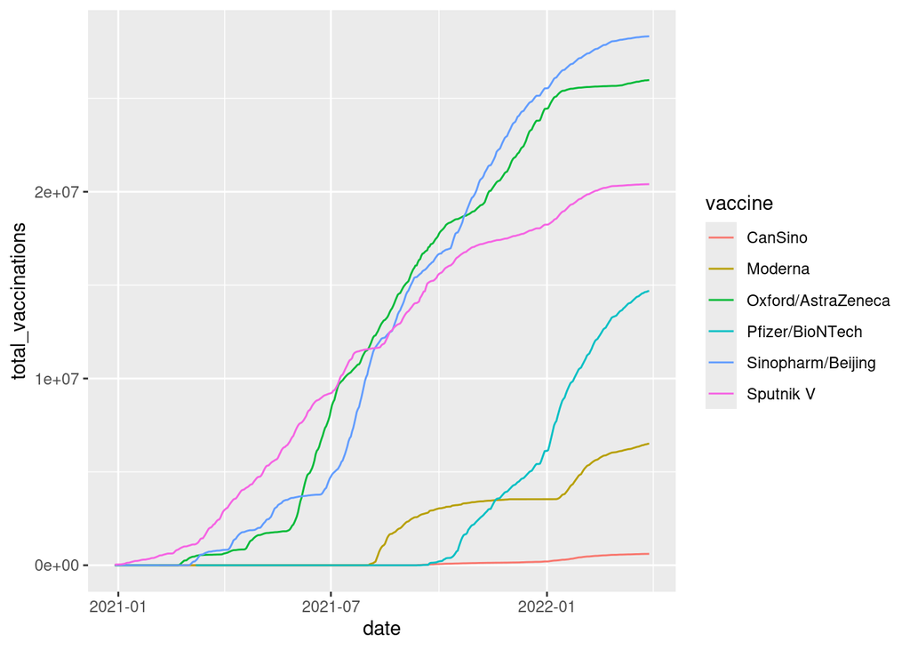

```r
## Argentina
p3 <- data |>
  filter(Country == "Argentina") |>
  ggplot(aes(x = date,
             y = total_vaccinations,
             color = vaccine)) +
  geom_line(aes(group = vaccine))
p3
```

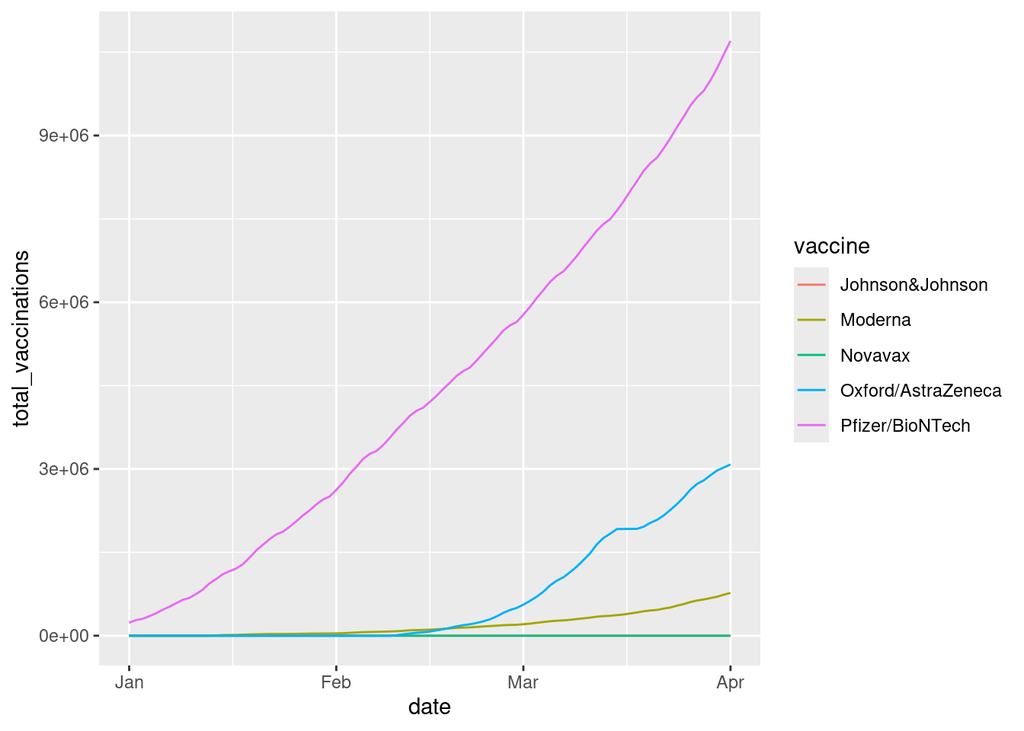

```r
## Germany the first 4 months of 2021
p4 <- data |>
  filter(Country == "Germany",
         date >= "2021-01-01" & date <= "2021-04-01") |>
  ggplot(aes(x = date,
             y = total_vaccinations,
             color = vaccine)) +
  geom_line(aes(group = vaccine))
p4
```

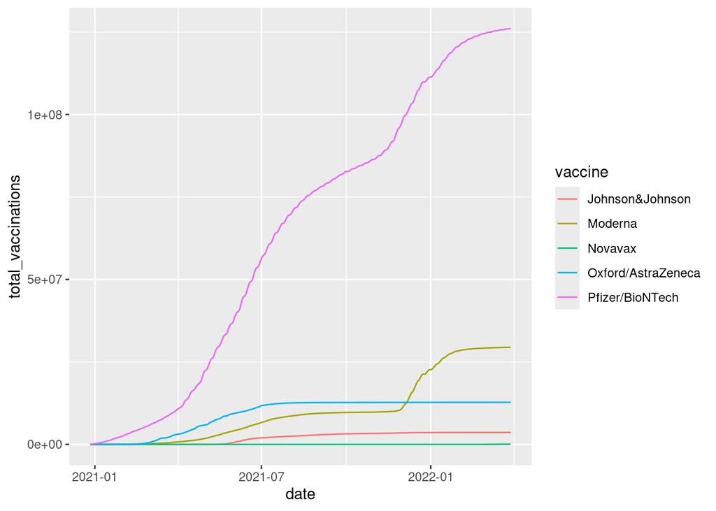

```r
## Germany
p5 <- data |>
  filter(Country == "Germany") |>
  ggplot(aes(x = date,
             y = total_vaccinations,
             color = vaccine)) +
  geom_line(aes(group = vaccine))
p5
```